# MPP-E1180 Lecture 6: Automatic Data Gathering + Cleaning

7 October 2016

## Objectives for the lesson

- Assignment info
- Review
- Benefits and challenges of open public data
- Automatic Data Gathering
- Tidying, Cleaning, and Merging data

## Assignment 1 General Times for Source Code Files

- Avoid including `?FUNCTION`, `search`, `View` and similar in your source files.
- Avoid straight `install.packages` calls.
- Remember to set the working directory!
- "dofile.R" is redundant. Use file names to indicate contents/position within file hierarchy.
- Use human readable labels on your plots.

## Working directory tip

You can have R automatically switch the working directory using `set_valid_wd` from the *repmis* package.

```r
# Create list of commonly used working directories
possible_dir <- c('/git_repos/Assignment1', 'C:\class\Assignment1')

# Set to first valid directory in the possible_dir vector
repmis::set_valid_wd(possible_dir)
```

## Splitting tip

You can split a vector by values of another variable using `split`.

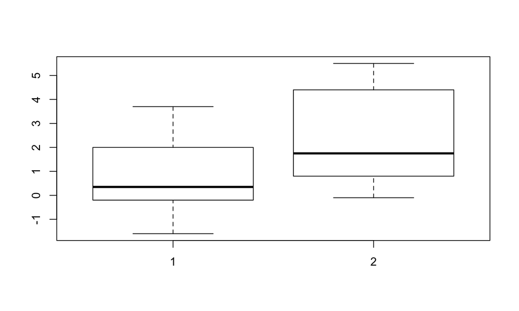

```r
library(dplyr)
split(sleep$extra, sleep$group) %>% boxplot()
```

## .gitignore tip

You can have Git ignore any file by including its file path (relative to the repo) in a file called *.gitignore*.

This is useful for files such as *.Rhistory* that you don't want to version control and which create pointless merge conflicts.

It's also useful for very large files that you can't store on GitHub.

## Serving HTML file tip

Serve an HTML file hosted on GitHub by putting its *raw* version through https://rawgit.com/.

## Assignment 2

**Proposal** for your Collaborative Research Project.

**Deadline:** 28 October

**Submit:** A (max) 2,000 word proposal created with **R Markdown**. The proposal will:

- Be written in R Markdown.
- State your research question. And justify why it is interesting.
- Provide a basic literature review (properly cited with BibTeX).
- Identify data sources and appropriate research methodologies for answering your question.

As always, submit the entire GitHub repo.

## Review

- Why is literate programming useful for reproducible research?
- What is a markup language?
- What is a code chunk?
- What is BibTeX?
- How is it an example of working hard so you can be lazy?
- What is caching?

## What is open public data?

Janssen, Charalabidis, and Zuiderwijk (2012, 258):

"Non-privacy-restricted and non-confidential data which is produced with public money and is made available without any restrictions on its usage or distribution."

## Some benefits of open public data

- **Greater returns** on public investment in data gathering.
- Better **coordination** within government.
- Provides **policy-makers with information** needed to address complex problems.
- ''**Mends the traditional separation** between public organizations and users''.

See Janssen, Charalabidis, and Zuiderwijk (2012, 261) for more.

## Mending separation between public and users

- **Assumes** that government **considers outside** views and information (including opposing) views as **constructive**.
- Results in government **giving up** (some) control and more **actively interacting** with its environment.

## An ideal for open public data

Not only should data be published, but potential **data users in society** should be **actively** sought for input on **improving government**.

## Challenges to open data

- **Lack of technological competence** to implement open data that is **useful**.
- **Worry** by bureaucrats that open data will be used to **criticise** them.
- **No incentives** for users to access the data. **Lack of skills** needed to use and understand the data.
- Balancing individual **privacy** concerns.

See Janssen, Charalabidis, and Zuiderwijk (2012, 262–63) for more.

## Recommended podcast

Max Ogden on the Request for Commits podcast discussing challenges faced working for the City of Boston with Code for America (https://changelog.com/rfc-6/).

## Accessing data

Social science and public data is becoming **increasingly open** and **accessible**.

However, the level of **accessibility varies**:

- use restrictions
- format
- documentation
- version control

## So . . .

We are only going to begin **scratching the surface** of the data access **obstacles** you are likely to encounter.

## Tie your research to your data

Do as much **data gathering** and **cleaning** as possible in R scripts:

- Fully document for reproducible research.
- Can find (inevitable) mistakes.
- Easy to update when the data is updated.
- Can apply methods to other data sets.

## ''Easy'' automatic data gathering

1. Plain-text data (e.g. CSV) stored at non-secure (http) URL, not embedded in a larger HTML marked-up website.
2. Plain-text data (e.g. CSV) stored at secure (https) URL, not embedded in a larger HTML marked-up website.
3. Data stored in a database with a well structured API (Application Programming Interface), that has a corresponding R package.

## Non-Secure URL Plain-text data

Use `read.table` or `read.csv` (just a wrapper for `read.csv` with `sep = ','`).

Include the URL rather than the file path.

```r
read.table('http://SOMEDATA.csv')
```

## Loading compressed plain-text data

You can download and load data files stored in compressed formats.

1. Download the compressed file into a **temporary file**.
2. Uncompress the file and pass it to `read.table`, `import`, etc.

## Loading compressed plain-text data

Load data from Pemstein, Meserve, and Melton (2010) in a file called *uds_summary.csv*.

```r
# For simplicity, store the URL in an object called 'URL'.
URL <- "http://bit.ly/1jXJgDh"

# Create a temporary file called 'temp' to put the zip file into.
temp <- tempfile()

# Download the compressed file into the temporary file.
download.file(URL, temp)

# Decompress the file and convert it into a data frame
UDSData <- read.csv(gzfile(temp, "uds_summary.csv"))

# Delete the temporary file.
unlink(temp)
```

## Secure (https) URL Plain-text data

Use `source_data` from the repmis package.

Data on GitHub is stored at secure URLs. Select the **RAW** URL:

```r
URL <- paste0('https://raw.githubusercontent.com/christophergandrud/',
        'LegislativeViolence/master/Data/LegViolenceDescriptives.csv')
main <- repmis::source_data(URL)
```

```
## SHA-1 hash of the downloaded data file is:
## 01cff579b689cea9ef9c98e433ce3122745cc5cb
```

## Versioning and reproducible research

Data maintainers (unfortunately) often change data sets with little or no documentation.

`source_data` allows you to notice these changes by assigning each file a unique [SHA1 Hash](http://en.wikipedia.org/wiki/SHA-1).

Each download can be checked against the Hash

```r
main <- repmis::source_data(URL,
                sha1 = '01cff579b689cea9ef9c98e433ce3122745cc5cb')
```

```
## Specified SHA-1 hash matches downloaded data file.
```

## Can also use rio

You can also use the rio package (but no sha1 hashing):

```r
main <- rio::import(URL)
```

## Excel Files

The `source_XlsxData` function in repmis does the same thing as `source_data`, but for Excel files.

Builds on `read.xlsx` for loading locally stored Excel files.

Can also use `import` from rio.

Note: Excel data often needs **a lot of cleaning** before it is useful for statistical/graphical analyses.

## Caching

`source_data` allows you to **cache** data with `cache = TRUE`.

This is useful if you are downloading a large data set/to speed up knitting.

Creates a locally stored version of the data set which is useful for reproducibility.

You can also cache data when you *knit* your R Markdown files.

Note: if you are caching a "large" data set in GitHub terms (>50 mb) consider ignoring it in a *.gitignore* file. Advanced users can store it using [Git Large File Storage](https://git-lfs.github.com/).

## Data APIs

API = Application Programming Interface, a documented way for programs to talk to each other.

Data API = a documented way to access data from one program stored with another.

## R and Data APIs

R can interact with most data APIs using the httr package.

Even easier: users have written API-specific packages to interact with particular data APIs.

## World Bank Development Indications with WDI

Access the [World Bank's Development Indicators](http://data.worldbank.org/indicator) with the WDI package.

Alternative Energy Use example:

```r
# Load WDI package
library(WDI)

# Per country alternative energy use as % of total energy use
AltEnergy <- WDI(indicator = 'EG.USE.COMM.CL.ZS')
```

Note: The indicator ID is at the end of the indicator's URL on the World Bank site.

## Financial Data with quantmod

The [quantmod](http://www.quantmod.com/) package allows you to access financial data from a variety of sources (e.g. [Yahoo Finance](http://finance.yahoo.com/), [Google Finance](https://www.google.com/finance), [US Federal Reserve's FRED database](http://research.stlouisfed.org/fred2/)).

```r
library(quantmod)

# Download Yen/USD exchange rate
YenDollar <- getSymbols(Symbols = 'DEXJPUS', src = 'FRED')
```

## Other API-R packages

There are many more R packages that interact with web data APIs.

For a good beginner list see: http://cran.r-project.org/web/views/WebTechnologies.html

## Working with non-table data

| Format | R packages |
| --- | --- |
| Excel, Stata, SPSS, SAS | rio |
| JSON | [jsonlite](https://cran.r-project.org/web/packages/jsonlite/index.html) |
| MySQL | RMySQL, [more info](http://www.jason-french.com/blog/2014/07/03/using-r-with-mysql-databases/) |
| [couchDB](http://couchdb.apache.org/) | R4CouchDB |

## Data Cleaning

The data you need for your analysis is often **not clean**.

Perhaps **80%** of data analysis is typically spent cleaning and preparing data (Dasu and Johnson 2003).

- This doesn't include the time taken to gather the data.

To help streamline this process Wickham (2014) laid out **principles of data tidying**.

- Links the **physical structure** of a data set to its **meaning** (semantics).

## Data structure

Many (not all) statistical data sets are organised into **rows** and **columns**.

Rows and columns have **no inherent meaning**.

## Data structure

| Person | treatmentA | treatmentB |
| --- | --- | --- |
| John Smith |  | 2 |
| Jane Doe | 16 | 11 |
| Mary Johnson | 3 | 1 |

| Treatment | John Smith | Jane Doe | Mary Johnson |
| --- | --- | --- | --- |
| treatmentA |  | 16 | 3 |
| treatmentB | 2 | 11 | 1 |

## Data semantics

Data sets are **collections of values**.

All values are assigned to a **variable** and an **observation**.

- **Variable**: all values measuring the same attribute across units
- **Observation**: all values measured within the same unit across attributes.

## Tidy data semantics + structure

1. Each variable forms a column.
2. Each observation forms a row.
3. Each type of observational unit forms a table.

## Tidy data

| Person | treatment | result |
| --- | --- | --- |
| John Smith | a |  |
| Jane Doe | a | 16 |
| Mary Johnson | a | 3 |
| John Smith | b | 2 |
| Jane Doe | b | 11 |
| Mary Johnson | b | 1 |

## Messy to Tidy data

First identify what your observations and variables are.

Then use R tools to convert your data into this format.

**tidyr** and its predecessor **reshape2** are particularly useful.

## Messy to tidy data

```r
# Create messy (wide) data
messy <- data.frame(
  person = c("John Smith", "Jane Doe", "Mary Johnson"),
  a = c(NA, 16, 3),
  b = c(2, 11, 1)
)

messy
```

```
##         person  a  b
## 1   John Smith NA  2
## 2     Jane Doe 16 11
## 3 Mary Johnson  3  1
```

## Messy to tidy data

```r
library(tidyr)

# Gather the data into tidy long format
tidy <- gather(messy, treatement, result, a:b)

tidy
```

```
##         person treatement result
## 1   John Smith          a     NA
## 2     Jane Doe          a     16
## 3 Mary Johnson          a      3
## 4   John Smith          b      2
## 5     Jane Doe          b     11
## 6 Mary Johnson          b      1
```

## Tidy to messy data

Sometimes it is useful to reverse this operation with `spread`.

```r
messyAgain <- spread(data = tidy, key = treatement,
                     value = result)

messyAgain
```

```
##         person  a  b
## 1     Jane Doe 16 11
## 2   John Smith NA  2
## 3 Mary Johnson  3  1
```

## Other issues cleaning data

Always **look at** and **poke your data**.

For example, see if:

- Missing values are designated with `NA`
- Variable classes are what you expect them to be.
- Distributions are what you expect them to be.

testdat can be useful for this, though not actively maintained.

## Merging data

Once you have tidy data frames, you can merge them for analysis.

In general: **each observation** must have a **unique identifier** to merge them on.

These identifiers **must match exactly across the data frames**.

## Merging data

```r
tail(AltEnergy, n = 3)
```

```
##      iso2c  country EG.USE.COMM.CL.ZS year
## 1741    ZW Zimbabwe          4.858643 2007
## 1742    ZW Zimbabwe          4.666912 2006
## 1743    ZW Zimbabwe          4.396196 2005
```

```r
tail(UDSData, n = 3)
```

```
##            country year cowcode      mean        sd    median     pct025
## 9135 Western Samoa 2006     990 0.2485397 0.2155926 0.2474691 -0.1702781
## 9136 Western Samoa 2007     990 0.2439135 0.2151686 0.2487054 -0.1874372
## 9137 Western Samoa 2008     990 0.2407623 0.2192563 0.2443505 -0.1881970
##         pct975
## 9135 0.6648156
## 9136 0.6571918
## 9137 0.6622615
```

## Create unique ID: country codes

Unique identifier will be [iso 2 letter country code](http://en.wikipedia.org/wiki/ISO_3166-1_alpha-2) and **year**.

Use the countrycode package to turn UDS data's [Correlates of War Country Code](http://www.correlatesofwar.org/datasets.htm) (`cowcode`) to `iso2c`.

```r
library(countrycode)

# Assign iso2c codes base on correlates of war codes
UDSData$iso2c <- countrycode(UDSData$cowcode, origin = 'cown',
                             destination = 'iso2c', warn = TRUE)
```

**NOTE**: Always check the data to make sure the correct codes have been applied!

## Creating IDs: geocodes

countrycode clearly only works for standardising country IDs

Other packages can be useful for standardising other unit IDs.

For example, `geocode` from [ggmap](http://journal.r-project.org/archive/2013-1/kahle-wickham.pdf) can be used to create latitude/longitudes for other geographic units:

```r
places <- c('Bavaria', 'Seoul', '6 Parisier Platz, Berlin')

ggmap::geocode(places, source = 'google')
```

```
##         lon      lat
## 1  11.49789 48.79045
## 2 126.97797 37.56654
## 3  13.37854 52.51701
```

## Creating IDs: Time

Time units may be important components of observation IDs.

Use the [lubridate](http://cran.r-project.org/web/packages/lubridate/vignettes/lubridate.html) package to standardise dates.

## Creating IDs: Time

```r
library(lubridate)

# Create time data
times <- c('Sep. 17 1980', 'March 23 2000', 'Nov. 3 2003')

mdy(times)
```

```
## [1] "1980-09-17" "2000-03-23" "2003-11-03"
```

Note: Times should always go from **longest to shortest** unit (e.g. YEAR-MONTH-DAY). Makes dates **sortable**.

## Merge data

```r
# Keep only desired variables
UDSData <- UDSData[, c('iso2c', 'year', 'median')]

names(UDSData)
```

```
## [1] "iso2c"  "year"   "median"
```

```r
Combined <- merge(AltEnergy, UDSData,
                  by = c('iso2c', 'year'))

head(Combined, n = 3)
```

```
##   iso2c year country EG.USE.COMM.CL.ZS    median
## 1    AD 2005 Andorra                NA 0.7785676
## 2    AD 2006 Andorra                NA 0.7860388
## 3    AD 2007 Andorra                NA 0.7853250
```

## Some merge details

By default, only observations in both data sets are kept. Use `all`, `all.x`, or `all.y` to keep non-merged observations.

Always **check your data** after a merge to see if you did what you wanted to do!

## Clean up

You many want to do some post merge cleaning. For example assign new variable names:

```r
names(Combined) <- c('iso2c', 'year', 'country',
                     'alt_energy_use',  'uds_median')
```

or

```r
Combined <- dplyr::rename(Combined, new_year = year)
```

And reorder variables

```r
Combined <- DataCombine::MoveFront(Combined, 'country')
```

## Seminar: Access web-based data

Thinking of your pair research project, write an R script to download **two or more** data sets from the web.

Either in the same or a linked R script **clean** and **merge** the data.

## References

Dasu, Tamraparni, and Theodore Johnson. 2003. *Exploratory Data Mining and Data Cleaning*. Hoboken, NJ: John Wiley & Sons.

Janssen, Marijn, Yannis Charalabidis, and Anneke Zuiderwijk. 2012. “Benefits, Adoption Barriers and Myths of Open Data and Open Government.” *Information Systems Management* 29 (4): 258–68.

Pemstein, Daniel, Stephen A. Meserve, and James Melton. 2010. “Democratic Compromise: A Latent Variable Analysis of Ten Measures of Regime Type.” *Political Analysis* 18 (4): 426–49.

Wickham, Hadley. 2014. “Tidy Data.” *Journal of Statistical Software* 59 (10): 1–23.